# Genome content

2025

## Mobile elements

Created with [MobileElementFinder](https://doi.org/10.1093/jac/dkaa390).

MobileElementFinder can detect the following types of MGEs: Insertion sequences (IS), Unit-transposons (Tn), Composite transposons (ComTn), Integrative Mobilizable Elements (IME) and Miniature Inverted Repeats (MITEs), Integrative and Conjugative Element (ICE), Composite Integrative and Mobilizable Element (CIME).

[Review of mobile elements](https://doi.org/10.1038/s41579-025-01157-y)

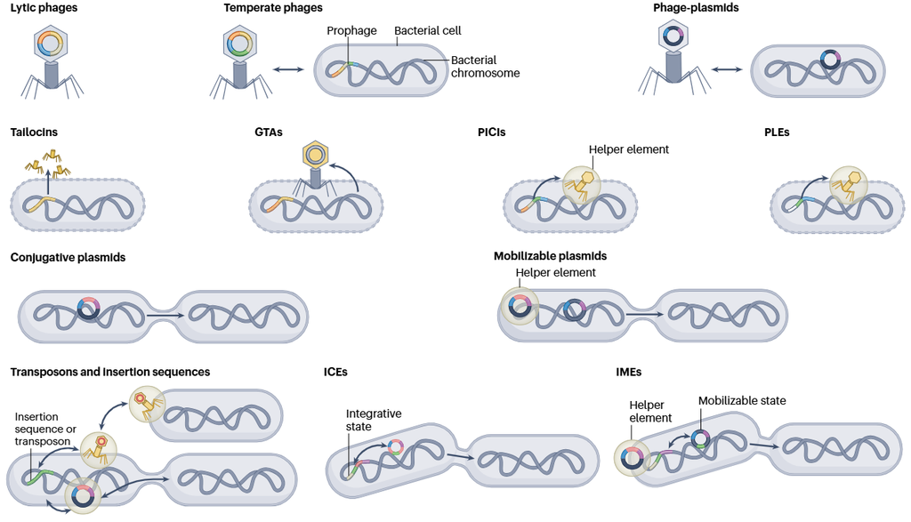

|  | Patient | mge_no | name | synonyms | prediction | type | allele_len | e_value | identity | coverage | gaps | substitution | contig | start | end | Group |
| --- | --- | --- | --- | --- | --- | --- | --- | --- | --- | --- | --- | --- | --- | --- | --- | --- |
| 1 | 13K | 1 | MITEEc1 |  | predicted | mite | 123 | 0 | 0.984 | 1 | 0 | 2 | 0171692_Run204_L02_121_1 [gcode=11] [topology=linear] | 266870 | 266992 | 0171692_Run204_L02_121 |
| 2 | 13K | 2 | MITEEc1 |  | predicted | mite | 123 | 0 | 0.992 | 1 | 0 | 1 | 0171692_Run204_L02_121_2 [gcode=11] [topology=linear] | 195683 | 195805 | 0171692_Run204_L02_121 |
| 3 | 13K | 3 | ISSen9 |  | predicted | insertion sequence | 767 | 0 | 0.926 | 0.999 | 1 | 56 | 0171692_Run204_L02_121_5 [gcode=11] [topology=linear] | 282941 | 283707 | 0171692_Run204_L02_121 |
| 4 | 13K | 4 | ISEch5 |  | predicted | insertion sequence | 704 | 0 | 0.881 | 0.99 | 1 | 83 | 0171692_Run204_L02_121_5 [gcode=11] [topology=linear] | 191500 | 192203 | 0171692_Run204_L02_121 |
| 5 | 13K | 5 | ISEc40 |  | predicted | insertion sequence | 1097 | 0 | 0.994 | 1 | 0 | 7 | 0171692_Run204_L02_121_11 [gcode=11] [topology=linear] | 125652 | 126748 | 0171692_Run204_L02_121 |
| 6 | 13K | 6 | ISCro4 |  | predicted | insertion sequence | 1278 | 0 | 0.809 | 0.978 | 29 | 219 | 0171692_Run204_L02_121_15 [gcode=11] [topology=linear] | 110049 | 111326 | 0171692_Run204_L02_121 |
| 7 | 13K | 7 | ISEc37 |  | predicted | insertion sequence | 1757 | 0 | 0.933 | 0.961 | 6 | 112 | 0171692_Run204_L02_121_19 [gcode=11] [topology=linear] | 4656 | 6412 | 0171692_Run204_L02_121 |
| 8 | 13K | 8 | IS30 | IS121 | predicted | insertion sequence | 1221 | 0 | 0.998 | 1 | 0 | 2 | 0171692_Run204_L02_121_19 [gcode=11] [topology=linear] | 3409 | 4629 | 0171692_Run204_L02_121 |
| 9 | 13K | 9 | ISKpn42 |  | predicted | insertion sequence | 1102 | 0 | 0.768 | 0.937 | 11 | 246 | 0171692_Run204_L02_121_19 [gcode=11] [topology=linear] | 52864 | 53965 | 0171692_Run204_L02_121 |
| 10 | 13K | 10 | ISKpn53 |  | predicted | insertion sequence | 946 | 0 | 1 | 1 | 0 | 0 | 0171692_Run204_L02_121_22 [gcode=11] [topology=linear] | 12250 | 13195 | 0171692_Run204_L02_121 |

[output cut: 913 more lines]

## Prophages

Created with [Phaster](https://doi.org/10.1093/nar/gkw387).

|  | Patient | REGION | REGION_LENGTH | COMPLETENESS | SPECIFIC_KEYWORD | REGION_POSITION | TRNA_NUM | TOTAL_PROTEIN_NUM | PHAGE_HIT_PROTEIN_NUM | HYPOTHETICAL_PROTEIN_NUM | PHAGE.HYPO_PROTEIN_PERCENTAGE | BACTERIAL_PROTEIN_NUM | ATT_SITE_SHOWUP | PHAGE_SPECIES_NUM | MOST_COMMON_PHAGE_NAME.hit_genes_count. | FIRST_MOST_COMMON_PHAGE_NUM | FIRST_MOST_COMMON_PHAGE_PERCENTAGE | GC_PERCENTAGE | Group |
| --- | --- | --- | --- | --- | --- | --- | --- | --- | --- | --- | --- | --- | --- | --- | --- | --- | --- | --- | --- |
| 1 | 13K | 1 | 18.9Kb | intact(140) | capsid,lysin,terminase,portal,head,tail | 4229946-4248867 | 0 | 29 | 15 | 14 | 100% | 0 | no | 4 | PHAGE_Shigel_SfII_NC_021857(11),PHAGE_Shigel_SfIV_NC_022749(10),PHAGE_Entero_SfV_NC_003444(9),PHAGE_Entero_SfI_NC_027339(9),PHAGE_Salmon_118970_sal3_NC_031940(9),PHAGE_Salmon_ST64B_NC_004313(5),PHAGE_… | 11 | 37.93% | 54.11% | 0171692_Run204_L02_121 |
| 2 | 13K | 2 | 15.3Kb | incomplete(20) | tail | 4549776-4565076 | 0 | 33 | 15 | 18 | 100% | 0 | no | 9 | PHAGE_Shigel_Sf6_NC_005344(6),PHAGE_Entero_Sf101_NC_027398(4),PHAGE_Salmon_g341c_NC_013059(3),PHAGE_Salmon_epsilon34_NC_011976(2),PHAGE_Entero_IME10_NC_019501(2),PHAGE_Salmon_UPF_BP1_NC_047875(2),PHAG… | 6 | 18.18% | 47.06% | 0171692_Run204_L02_121 |
| 3 | 13K | 3 | 42.8Kb | incomplete(20) |  | 4936982-4979840 | 0 | 29 | 7 | 22 | 100% | 0 | yes | 3 | PHAGE_Entero_lambda_NC_001416(5),PHAGE_Entero_DE3_NC_042057(5),PHAGE_Entero_HK630_NC_019723(5),PHAGE_Entero_HK629_NC_019711(5),PHAGE_Entero_HK225_NC_019717(4),PHAGE_Phage_Gifsy_1_NC_010392(1),PHAGE_Sa… | 5 | 17.24% | 52.18% | 0171692_Run204_L02_121 |
| 4 | 13K | 4 | 7.8Kb | incomplete(60) | tail,head | 5057188-5065049 | 0 | 21 | 7 | 14 | 100% | 0 | no | 4 | PHAGE_Entero_cdtI_NC_009514(4),PHAGE_Entero_HK630_NC_019723(3),PHAGE_Entero_DE3_NC_042057(3),PHAGE_Entero_lambda_NC_001416(3),PHAGE_Entero_mEp460_NC_019716(3),PHAGE_Entero_SfV_NC_003444(2),PHAGE_Enter… | 4 | 19.04% | 53.12% | 0171692_Run204_L02_121 |
| 5 | 92K | 1 | 33.7Kb | intact(106) |  | 664031-697741 | 0 | 44 | 36 | 8 | 100% | 0 | yes | 6 | PHAGE_Klebsi_4LV2017_NC_047818(27),PHAGE_Escher_500465_1_NC_049342(22),PHAGE_Klebsi_ST512_KPC3phi13.2_NC_049452(18),PHAGE_Salmon_Fels_2_NC_010463(18),PHAGE_Salmon_SEN8_NC_047753(16),PHAGE_Klebsi_ST437… | 15 | 61.36% | 50.44% | 0171692_Run204_L02_123 |
| 6 | 92K | 2 | 11.7Kb | incomplete(60) | transposase,terminase,portal | 4846725-4858521 | 0 | 13 | 7 | 6 | 100% | 0 | no | 4 | PHAGE_Entero_mEp213_NC_019720(4),PHAGE_Entero_c_1_NC_019706(4),PHAGE_Entero_mEp460_NC_019716(2),PHAGE_Entero_cdtI_NC_009514(2),PHAGE_Shigel_Sf6_NC_005344(1),PHAGE_Entero_VT2_Sakai_NC_000902(1),PHAGE_E… | 4 | 30.76% | 52.73% | 0171692_Run204_L02_123 |
| 7 | 92K | 3 | 6.7Kb | questionable(70) | transposase,tail | 5109931-5116641 | 0 | 18 | 9 | 9 | 100% | 0 | no | 6 | PHAGE_Entero_BP_4795_NC_004813(2),PHAGE_Stx2_c_1717_NC_011357(2),PHAGE_Entero_HK225_NC_019717(1),PHAGE_Salmon_VSe12_NC_048794(1),PHAGE_Escher_Lys12581Vzw_NC_049917(1),PHAGE_Entero_JenP1_NC_029028(1),P… | 4 | 11.11% | 53.12% | 0171692_Run204_L02_123 |
| 8 | 92K | 4 | 6.1Kb | incomplete(60) | tail,transposase | 5127448-5133607 | 0 | 21 | 6 | 15 | 100% | 0 | no | 4 | PHAGE_Stx2_c_1717_NC_011357(2),PHAGE_Phage_Gifsy_1_NC_010392(2),PHAGE_Entero_HK629_NC_019711(2),PHAGE_Entero_DE3_NC_042057(2),PHAGE_Entero_lambda_NC_001416(2),PHAGE_Phage_Gifsy_2_NC_010393(2),PHAGE_En… | 2 | 9.52% | 52.95% | 0171692_Run204_L02_123 |
| 9 | 847 | 1 | 7.5Kb | incomplete(30) | tail,integrase | 2551151-2558728 | 0 | 10 | 6 | 4 | 100% | 0 | yes | 5 | PHAGE_Entero_mEp460_NC_019716(2),PHAGE_Escher_P13374_NC_018846(2),PHAGE_Escher_ArgO145_NC_049918(2),PHAGE_Shigel_SfIV_NC_022749(1),PHAGE_Entero_SfV_NC_003444(1),PHAGE_Entero_BP_4795_NC_004813(1),PHAGE… | 2 | 20% | 47.68% | 0171692_Run204_L02_125 |
| 10 | 847 | 2 | 12.7Kb | incomplete(10) |  | 4438501-4451204 | 0 | 16 | 10 | 6 | 100% | 0 | no | 3 | PHAGE_Entero_lambda_NC_001416(7),PHAGE_Entero_HK629_NC_019711(7),PHAGE_Entero_HK630_NC_019723(7),PHAGE_Entero_DE3_NC_042057(6),PHAGE_Entero_N15_NC_001901(3),PHAGE_Entero_HK225_NC_019717(2),PHAGE_Enter… | 8 | 43.75% | 56.81% | 0171692_Run204_L02_125 |

[output cut: 132 more lines]

## Plasmides

Created with [PlasmideFinder](https://cge.food.dtu.dk/services/PlasmidFinder).

These tools will facilitate bacterial typing based on draft genomes of multi-drug resistant Enterobacteriaceae by a rapid detection of known plasmid types.Replicon sequences were collected from 559 fully sequenced plasmids present at the NCBI nucleotide database associated with the family Enterobacteriaceae, to build a consensus database for integration into a web-tool called PlasmidFinder usable for replicon sequence analysis of raw as well as group of contigs or completely assembled and closed plasmids sequencing data. The PlasmidFinder database currently consists of 116 replicon sequences that match at least at 80% nucleotide identity with all replicon sequences identified in the 559 fully sequenced plasmids.

|  | Patient | name | identity | coverage | alignment_length | ref_gene_length | ref_id | ref_acc | query_id | query_start_pos | query_end_pos | Group |
| --- | --- | --- | --- | --- | --- | --- | --- | --- | --- | --- | --- | --- |
| 1 | 13K | IncFIC(FII) | 95.79 | 99.6 | 499 | 499 | IncFIC(FII)_1__AP001918 | AP001918 | 0171692_Run204_L02_121_19 [gcode=11] [topology=linear] | 9014 | 9510 | 0171692_Run204_L02_121 |
| 2 | 13K | IncFIB(AP001918) | 97.36 | 100 | 682 | 682 | IncFIB(AP001918)_1__AP001918 | AP001918 | 0171692_Run204_L02_121_33 [gcode=11] [topology=linear] | 25554 | 26235 | 0171692_Run204_L02_121 |
| 3 | 92K | IncFII(pRSB107) | 96.18 | 100 | 262 | 261 | IncFII(pRSB107)_1__AJ851089 | AJ851089 | 0171692_Run204_L02_123_54 [gcode=11] [topology=linear] | 10969 | 11230 | 0171692_Run204_L02_123 |
| 4 | 92K | IncFII(pEH01) | 99.04 | 100 | 726 | 726 | IncFII(pEH01)_1__CP063521.1 | CP063521.1 | 0171692_Run204_L02_123_68 [gcode=11] [topology=linear] | 3548 | 4273 | 0171692_Run204_L02_123 |
| 5 | 92K | IncFIB(AP001918) | 96.63 | 100 | 682 | 682 | IncFIB(AP001918)_1__AP001918 | AP001918 | 0171692_Run204_L02_123_83 [gcode=11] [topology=linear] | 7381 | 8062 | 0171692_Run204_L02_123 |
| 6 | 92K | Col156 | 98.7 | 100 | 154 | 154 | Col156_1__NC_009781 | NC009781 | 0171692_Run204_L02_123_99 [gcode=11] [topology=linear] | 3637 | 3790 | 0171692_Run204_L02_123 |
| 7 | 92K | IncX10 | 90.27 | 100 | 524 | 524 | IncX10_1__OQ821188.1 | OQ821188.1 | 0171692_Run204_L02_123_115 [gcode=11] [topology=linear] | 6421 | 6944 | 0171692_Run204_L02_123 |
| 8 | 92K | IncX1 | 94.39 | 100 | 374 | 374 | IncX1_1__EU370913 | EU370913 | 0171692_Run204_L02_123_115 [gcode=11] [topology=linear] | 7152 | 7525 | 0171692_Run204_L02_123 |
| 9 | 92K | Col156 | 91.56 | 100 | 154 | 154 | Col156_1__NC_009781 | NC009781 | 0171692_Run204_L02_123_121 [gcode=11] [completeness=complete] [topology=circular] [plasmid-name=unnamed1] | 511 | 664 | 0171692_Run204_L02_123 |
| 10 | 92K | Col156 | 94.81 | 100 | 154 | 154 | Col156_1__NC_009781 | NC009781 | 0171692_Run204_L02_123_136 [gcode=11] [topology=linear] | 1267 | 1420 | 0171692_Run204_L02_123 |

[output cut: 182 more lines]

## Antibiotic resistance

Created with [ResFinder](https://doi.org/10.1093/jac/dkaa345).

|  | Patient | Antimicrobial | Class | WGS.predicted.phenotype | Match | Genetic.background |
| --- | --- | --- | --- | --- | --- | --- |
| 1 | 13K | tobramycin | aminoglycoside | No resistance | 0 |  |
| 2 | 13K | streptomycin | aminoglycoside | No resistance | 0 |  |
| 3 | 13K | amikacin | aminoglycoside | No resistance | 0 |  |
| 4 | 13K | isepamicin | aminoglycoside | No resistance | 0 |  |
| 5 | 13K | dibekacin | aminoglycoside | No resistance | 0 |  |
| 6 | 13K | kanamycin | aminoglycoside | No resistance | 0 |  |
| 7 | 13K | neomycin | aminoglycoside | No resistance | 0 |  |
| 8 | 13K | lividomycin | aminoglycoside | No resistance | 0 |  |
| 9 | 13K | paromomycin | aminoglycoside | No resistance | 0 |  |
| 10 | 13K | ribostamycin | aminoglycoside | No resistance | 0 |  |

[output cut: 3590 more lines]

|  | Antimicrobial | 13K | 92K | KOJ | 847 | ANB | CRA | UN5 | TIM | IPO | LAP | HIM | CHA | BRU | ZVL | OSM | NUR | LOK | ZAI | ARK | GOR | BA2 | OTR | CHE | BOG | UN3 | GOK | RAI | MUL | … |
| --- | --- | --- | --- | --- | --- | --- | --- | --- | --- | --- | --- | --- | --- | --- | --- | --- | --- | --- | --- | --- | --- | --- | --- | --- | --- | --- | --- | --- | --- | --- |
| 1 | tobramycin | No resistance | No resistance | No resistance | No resistance | No resistance | Resistant | No resistance | No resistance | No resistance | No resistance | No resistance | No resistance | No resistance | No resistance | No resistance | Resistant | No resistance | No resistance | No resistance | No resistance | No resistance | No resistance | Resistant | No resistance | Resistant | No resistance | No resistance | No resistance | … |
| 2 | streptomycin | No resistance | No resistance | Resistant | No resistance | Resistant | Resistant | No resistance | Resistant | Resistant | Resistant | No resistance | No resistance | Resistant | No resistance | No resistance | Resistant | Resistant | No resistance | Resistant | No resistance | Resistant | No resistance | Resistant | Resistant | Resistant | No resistance | No resistance | No resistance | … |
| 3 | amikacin | No resistance | No resistance | No resistance | No resistance | No resistance | No resistance | No resistance | No resistance | No resistance | No resistance | No resistance | No resistance | No resistance | No resistance | No resistance | No resistance | No resistance | No resistance | No resistance | No resistance | No resistance | No resistance | Resistant | No resistance | Resistant | No resistance | No resistance | No resistance | … |
| 4 | isepamicin | No resistance | No resistance | No resistance | No resistance | No resistance | No resistance | No resistance | No resistance | No resistance | No resistance | No resistance | No resistance | No resistance | No resistance | No resistance | No resistance | No resistance | No resistance | No resistance | No resistance | No resistance | No resistance | No resistance | No resistance | No resistance | No resistance | No resistance | No resistance | … |
| 5 | dibekacin | No resistance | No resistance | No resistance | No resistance | No resistance | Resistant | No resistance | No resistance | No resistance | No resistance | No resistance | No resistance | No resistance | No resistance | No resistance | Resistant | No resistance | No resistance | No resistance | No resistance | No resistance | No resistance | Resistant | No resistance | Resistant | No resistance | No resistance | No resistance | … |
| 6 | kanamycin | No resistance | No resistance | No resistance | No resistance | No resistance | No resistance | No resistance | No resistance | No resistance | No resistance | No resistance | No resistance | No resistance | No resistance | No resistance | No resistance | No resistance | No resistance | No resistance | No resistance | No resistance | No resistance | No resistance | No resistance | No resistance | No resistance | No resistance | No resistance | … |
| 7 | neomycin | No resistance | No resistance | No resistance | No resistance | No resistance | No resistance | No resistance | No resistance | No resistance | No resistance | No resistance | No resistance | No resistance | No resistance | No resistance | No resistance | No resistance | No resistance | No resistance | No resistance | No resistance | No resistance | No resistance | No resistance | No resistance | No resistance | No resistance | No resistance | … |
| 8 | lividomycin | No resistance | No resistance | No resistance | No resistance | No resistance | No resistance | No resistance | No resistance | No resistance | No resistance | No resistance | No resistance | No resistance | No resistance | No resistance | No resistance | No resistance | No resistance | No resistance | No resistance | No resistance | No resistance | No resistance | No resistance | No resistance | No resistance | No resistance | No resistance | … |
| 9 | paromomycin | No resistance | No resistance | No resistance | No resistance | No resistance | No resistance | No resistance | No resistance | No resistance | No resistance | No resistance | No resistance | No resistance | No resistance | No resistance | No resistance | No resistance | No resistance | No resistance | No resistance | No resistance | No resistance | No resistance | No resistance | No resistance | No resistance | No resistance | No resistance | … |
| 10 | ribostamycin | No resistance | No resistance | No resistance | No resistance | No resistance | No resistance | No resistance | No resistance | No resistance | No resistance | No resistance | No resistance | No resistance | No resistance | No resistance | No resistance | No resistance | No resistance | No resistance | No resistance | No resistance | No resistance | No resistance | No resistance | No resistance | No resistance | No resistance | No resistance | … |

[output cut: 80 more lines]

## Virulence factors

Created with [VirulenceFinder](https://doi.org/10.1128/spectrum.03724-23).

|  | Patient | name | ref_acc | function | identity | coverage |
| --- | --- | --- | --- | --- | --- | --- |
| 1 | 13K | neuC | ADUG01000366 | Polysialic acid capsule biosynthesis protein | 100 | 100 |
| 2 | 13K | kpsE | CP000243 | Capsule polysaccharide export inner-membrane protein | 100 | 100 |
| 3 | 13K | terC | MG591698 | Tellurium ion resistance protein | 97.4947807933194 | 99.17184265010351 |
| 4 | 13K | nlpI | CP000243 | lipoprotein NlpI precursor | 100 | 100 |
| 5 | 13K | kpsMII_K1 | M57382 | Polysialic acid transport protein; Group 2 capsule | 100 | 100 |
| 6 | 13K | terC | CP000468 | Tellurium ion resistance protein | 100 | 100 |
| 7 | 13K | ompT | CP000243 | Outer membrane protease (protein protease 7) | 100 | 100 |
| 8 | 13K | focCsfaE | CP001969 | S fimbrial/F1C minor subunit | 100 | 100 |
| 9 | 13K | sfaD | CP010315 | S fimbrial/F1C minor subunit | 100 | 100 |
| 10 | 13K | sfaS | CP000243 | S-fimbriae minor subunit | 99.79674796747967 | 100 |

[output cut: 1177 more lines]

|  | name | 13K | 92K | KOJ | 847 | ANB | CRA | UN5 | TIM | IPO | LAP | HIM | CHA | BRU | ZVL | OSM | NUR | LOK | ZAI | ARK | GOR | BA2 | OTR | CHE | BOG | UN3 | GOK | RAI | MUL | … |
| --- | --- | --- | --- | --- | --- | --- | --- | --- | --- | --- | --- | --- | --- | --- | --- | --- | --- | --- | --- | --- | --- | --- | --- | --- | --- | --- | --- | --- | --- | --- |
| 1 | neuC | 1 | 1 | 0 | 0 | 0 | 0 | 1 | 0 | 1 | 0 | 0 | 0 | 0 | 0 | 0 | 0 | 0 | 0 | 0 | 0 | 0 | 0 | 0 | 0 | 0 | 0 | 0 | 0 | … |
| 2 | kpsE | 1 | 1 | 0 | 0 | 0 | 1 | 1 | 1 | 1 | 0 | 1 | 1 | 1 | 1 | 0 | 1 | 1 | 1 | 0 | 0 | 1 | 0 | 1 | 1 | 0 | 0 | 1 | 0 | … |
| 3 | terC | 1 | 1 | 1 | 1 | 1 | 1 | 1 | 1 | 1 | 1 | 1 | 1 | 1 | 1 | 1 | 1 | 1 | 1 | 1 | 1 | 1 | 1 | 1 | 1 | 1 | 1 | 1 | 1 | … |
| 4 | nlpI | 1 | 1 | 1 | 1 | 1 | 1 | 1 | 1 | 1 | 1 | 1 | 1 | 1 | 1 | 1 | 1 | 1 | 1 | 1 | 1 | 1 | 1 | 1 | 1 | 1 | 1 | 1 | 1 | … |
| 5 | kpsMII_K1 | 1 | 1 | 0 | 0 | 0 | 0 | 1 | 0 | 1 | 0 | 0 | 0 | 0 | 0 | 0 | 0 | 0 | 0 | 0 | 0 | 0 | 0 | 0 | 0 | 0 | 0 | 0 | 0 | … |
| 6 | ompT | 1 | 1 | 0 | 0 | 1 | 1 | 1 | 0 | 1 | 0 | 0 | 0 | 1 | 0 | 0 | 1 | 1 | 1 | 0 | 0 | 1 | 0 | 1 | 1 | 0 | 0 | 0 | 0 | … |
| 7 | focCsfaE | 1 | 0 | 0 | 0 | 0 | 0 | 0 | 0 | 0 | 0 | 0 | 0 | 0 | 0 | 0 | 0 | 0 | 0 | 0 | 0 | 0 | 0 | 0 | 0 | 0 | 0 | 0 | 0 | … |
| 8 | sfaD | 1 | 0 | 0 | 0 | 0 | 0 | 0 | 0 | 0 | 0 | 0 | 0 | 0 | 0 | 0 | 0 | 0 | 0 | 0 | 0 | 0 | 0 | 0 | 0 | 0 | 0 | 0 | 0 | … |
| 9 | sfaS | 1 | 0 | 0 | 0 | 0 | 0 | 0 | 0 | 0 | 0 | 0 | 0 | 0 | 0 | 0 | 0 | 0 | 0 | 0 | 0 | 0 | 0 | 0 | 0 | 0 | 0 | 0 | 0 | … |
| 10 | yehB | 1 | 0 | 1 | 1 | 1 | 1 | 0 | 1 | 1 | 0 | 0 | 1 | 1 | 1 | 1 | 1 | 1 | 1 | 1 | 0 | 1 | 1 | 1 | 1 | 1 | 1 | 1 | 1 | … |

[output cut: 104 more lines]

```
## Time difference of 5 secs
```